# Predicting Shelter Animal Outcomes - Maggie Everett

#### BIA 6303 - Predictive Models

For my final project, I chose to do the Kaggle competition - Predicting Shelter Animal Outcomes. As an avid animal lover, an owner of 3 rescue babies, and a past employee of an animal shelter, this competition immediately caught my eye.

# Table of Contents

```python
%%javascript
$.getScript('https://kmahelona.github.io/ipython_notebook_goodies/ipython_notebook_toc.js')
```

#### Import Necessary Libraries

```python
import pandas as pd
import numpy as np
import os
import matplotlib.pyplot as plt
%matplotlib inline
from sklearn import preprocessing
from sklearn.model_selection  import train_test_split, cross_val_score, KFold
from sklearn.svm import SVC
import seaborn as sns

# Hide warnings
import warnings
warnings.filterwarnings('ignore')

import time
```

```python
os.chdir("/Users/maggieeverett/Documents/final2/") # set working directory
```

#### Read in data

While reading in my data, I am going to add "Outcome Type" to the test set so I can combine the two datasets for pre-processing. I will split them back out prior to creating my models.

```python
df = pd.read_csv('train.csv')

df_test = pd.read_csv('test.csv')
df_test['OutcomeType'] = ''
```

```python
df_ID = pd.read_csv('test.csv')
df_ID = df_ID[['ID']]
```

```python
del df['AnimalID']
del df['OutcomeSubtype']

del df_test['ID']
```

```python
df1 = pd.concat([df, df_test], axis=0) # combine the two data frames
df1.head()
```

|  | AgeuponOutcome | AnimalType | Breed | Color | DateTime | Name | OutcomeType | SexuponOutcome |
| --- | --- | --- | --- | --- | --- | --- | --- | --- |
| 0 | 1 year | Dog | Shetland Sheepdog Mix | Brown/White | 2014-02-12 18:22:00 | Hambone | Return_to_owner | Neutered Male |
| 1 | 1 year | Cat | Domestic Shorthair Mix | Cream Tabby | 2013-10-13 12:44:00 | Emily | Euthanasia | Spayed Female |
| 2 | 2 years | Dog | Pit Bull Mix | Blue/White | 2015-01-31 12:28:00 | Pearce | Adoption | Neutered Male |
| 3 | 3 weeks | Cat | Domestic Shorthair Mix | Blue Cream | 2014-07-11 19:09:00 | NaN | Transfer | Intact Male |
| 4 | 2 years | Dog | Lhasa Apso/Miniature Poodle | Tan | 2013-11-15 12:52:00 | NaN | Transfer | Neutered Male |

## Pre-Processing and EDA

To start, I want to see what my target variable looks like. The intent is to predict the outcome for a shelter animal, the possible outcomes are:

```
- Death (not due to euthanasia)
- Euthanasia
- Return to owner
- Transfer
- Adoption
```

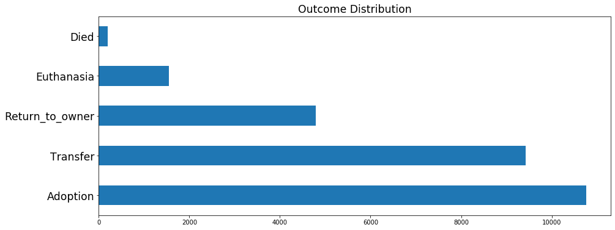

```python
df['OutcomeType'].value_counts().plot(kind = 'barh',figsize = (15,6))

plt.yticks(fontsize = 'xx-large')
plt.title('Outcome Distribution', fontsize = 'xx-large')
```

In this data, most animals are either transferred or adopted. This is great for the animal's sake, but may pose a problem for me later on down the road. Having such an imbalanced dataset will definitely have an affect on my model; death and euthanasia may be rather hard to predict since they represent such a small segment of the data.

Next, I want to see what kinds of animals are considered. A lot of animal shelters take in much more than just dogs and cats; they can take in anything from reptiles, rabbits, and even chickens.

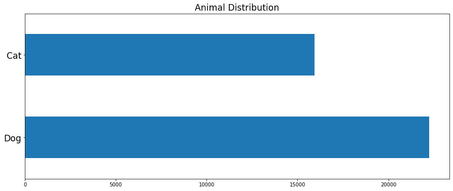

```python
df1['AnimalType'].value_counts().plot(kind = 'barh',figsize = (15,6))

plt.yticks(fontsize = 'xx-large')
plt.title('Animal Distribution', fontsize = 'xx-large')
```

The distribution between cats and dogs is much more balanced than the adoption outcome.

Next, I want to view the distribution of gender.

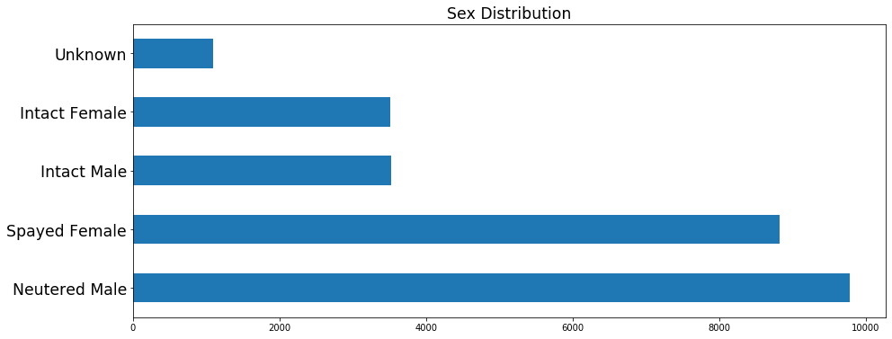

```python
df['SexuponOutcome'].value_counts().plot(kind = 'barh',figsize = (15,6))

plt.yticks(fontsize = 'xx-large')
plt.title('Sex Distribution', fontsize = 'xx-large')
```

The "Sex Upon Outcome" column is an interesting one, since it includes not only gender but also the sterilization (spayed or neutered) status of the animal. This column will likely need to be separated into 2 different columns down the road, I believe both of these will have predictive power.

#### Null Values

Now, I want to see how many null values I'm dealing with so I can decide how to handle them.

```python
print('Null Values:')
missing_values = df1.columns[df1.isnull().any()].tolist()
print(df1[missing_values].isna().sum())
print('')
```

```
Null Values:
AgeuponOutcome       24
Name              10916
SexuponOutcome        1
dtype: int64
```

I'm concerned that so many names are missing, as that can have a huge impact on whether a family knows their dog is at a shelter, or hurt their chances with adoption. However, the name itself likely doesn't have any predictive power, so I will dummy it.

```python
df1['Name'].fillna(0, inplace=True) # replace all NA values with 0

df2 = pd.DataFrame(df1['Name'])
df2 = df2.applymap(lambda x: 1 if x != 0 else x) # replace any actual name with 1

df1['Name'] = df2['Name']
```

Evaluate null values again:

```python
print('Null Values:')
missing_values = df1.columns[df1.isnull().any()].tolist()
print(df1[missing_values].isna().sum())
print('')
```

```
Null Values:
AgeuponOutcome    24
SexuponOutcome     1
dtype: int64
```

After dummying the "Name" column, I hardly have any null values left. Since it is such a small amount for a rather large dataset, I'm going to go ahead and remove the 25 null values.

```python
df1 = df1.dropna() # drop null values
print('Shape after removal:')
df1.shape
```

```
Shape after removal:
```

```
(38160, 8)
```

#### Pre-processing - Age

The age column is rather scattered within the dataset, some value are listed as days whereas others are months or years. I want to split it up and get all values in the same format.

```python
df1['AgeuponOutcome_Time']= df1['AgeuponOutcome'].str.split(' ').str.get(1) # separate by number and category

df1['AgeuponOutcome_num'] = df1['AgeuponOutcome'].str.split(' ').str.get(0)
```

```python
print(df1.groupby('AgeuponOutcome_Time').size())

df1['AgeuponOutcome_Time'] = df1['AgeuponOutcome_Time'].map({'day': 1, 'days': 1, 'month': 31, 'months':31, 'week': 7, 'weeks': 7, 'year':365, 'years':365})
```

```
AgeuponOutcome_Time
day          84
days        483
month      1782
months    11995
week        220
weeks      2404
year       5737
years     15455
dtype: int64
```

Since I split the number and the value (week, day, month, year) up, I assigned each value with the following:

```
- day = 1
- week = 7
- month = 31
- year = 365
```

While there are some months that only have 30 days, majority have 31. Splitting the variables up like this will allow me to multiply them by their correct value. Now that everything is split, I can properly multiply it by the value to get the correct age by number of days. (IE: 1 year = 365 * 1 = 365 days)

```python
df1.AgeuponOutcome_Time = df1.AgeuponOutcome_Time.astype(int) # make these values an integer so I can multiply

df1.AgeuponOutcome_num = df1.AgeuponOutcome_num.astype(int)
```

```python
df1['totalweeks'] = (df1['AgeuponOutcome_Time']) * (df1['AgeuponOutcome_num'])
```

```python
df1.head()
```

|  | AgeuponOutcome | AnimalType | Breed | Color | DateTime | Name | OutcomeType | SexuponOutcome | AgeuponOutcome_Time | AgeuponOutcome_num | totalweeks |
| --- | --- | --- | --- | --- | --- | --- | --- | --- | --- | --- | --- |
| 0 | 1 year | Dog | Shetland Sheepdog Mix | Brown/White | 2014-02-12 18:22:00 | 1 | Return_to_owner | Neutered Male | 365 | 1 | 365 |
| 1 | 1 year | Cat | Domestic Shorthair Mix | Cream Tabby | 2013-10-13 12:44:00 | 1 | Euthanasia | Spayed Female | 365 | 1 | 365 |
| 2 | 2 years | Dog | Pit Bull Mix | Blue/White | 2015-01-31 12:28:00 | 1 | Adoption | Neutered Male | 365 | 2 | 730 |
| 3 | 3 weeks | Cat | Domestic Shorthair Mix | Blue Cream | 2014-07-11 19:09:00 | 0 | Transfer | Intact Male | 7 | 3 | 21 |
| 4 | 2 years | Dog | Lhasa Apso/Miniature Poodle | Tan | 2013-11-15 12:52:00 | 0 | Transfer | Neutered Male | 365 | 2 | 730 |

```python
# Remove unnecessary columns now that I have the data I need
del df1['AgeuponOutcome']
del df1['AgeuponOutcome_Time']
del df1['AgeuponOutcome_num']
```

Now, I have each animal's age by number of I want to make the age variable a little easier to deal with. Most people looking for a new pet are seeking younger animals, and oftentimes, it's harder for adult animals to get adopted. I believe this will have some predictive power within my model, so I'm going to split the two up. Any animal younger than 1 year is considered a puppy, while animals over 1 year old are typically considered adults.

```python
def totalweeks1(x):
    if x <= 365:
        return 'puppy'
    else:
        return 'adult'

df1['totalweeks'] = df1.totalweeks.apply(totalweeks1)
```

#### Pre-processing - Breed & Color

I want to see how many different breeds are within the dataset. A lot of times, shelters are unsure and have to make their best guess.

```python
print(df1.groupby('Breed').size())
print('')
print(df1.groupby('Color').size())
```

```
Breed
Abyssinian Mix                              3
Affenpinscher Mix                           6
Afghan Hound Mix                            1
Airedale Terrier                            1
Airedale Terrier Mix                        7
                                           ..
Yorkshire Terrier/Parson Russell Terrier    1
Yorkshire Terrier/Pomeranian                1
Yorkshire Terrier/Rat Terrier               6
Yorkshire Terrier/Shih Tzu                  1
Yorkshire Terrier/Toy Poodle                1
Length: 1678, dtype: int64

Color
Agouti                 2
Agouti/Brown Tabby     1
Apricot               33
Apricot/Brown          2
Apricot/Tricolor       1
                      ..
Yellow/Black           1
Yellow/Gray            2
Yellow/Tan             1
Yellow/White          70
Yellow/Yellow          1
Length: 411, dtype: int64
```

```python
df1.nunique()
```

```
AnimalType            2
Breed              1678
Color               411
DateTime          31398
Name                  2
OutcomeType           6
SexuponOutcome        5
totalweeks            2
dtype: int64
```

There are 1600+ unique breeds within the dataset and 400+ unique colors. In order to avoid having an excessive amount of variables, I want to simpify this variable by narrowing it down between mixed breeds, bully breeds, and pure breeds.

The reason I want to break this down into these 3 categories is a lot of animals won't adopt a "bully" breed - IE, a pitbull. I want to see if this has any predictive power within the model.

```python
breeds = []
#for each row in the column
for item in df1['Breed']:
    if 'Bull' in item.split():
        breeds.append('bully')
    elif 'Mix' in item.split():
        breeds.append('mix')
    else:
        breeds.append('pure')

#add the new list to our column in the dataframe
df1['breed1'] = breeds
del df1['Breed']
```

```python
df1.head()
```

|  | AnimalType | Color | DateTime | Name | OutcomeType | SexuponOutcome | totalweeks | breed1 |
| --- | --- | --- | --- | --- | --- | --- | --- | --- |
| 0 | Dog | Brown/White | 2014-02-12 18:22:00 | 1 | Return_to_owner | Neutered Male | puppy | mix |
| 1 | Cat | Cream Tabby | 2013-10-13 12:44:00 | 1 | Euthanasia | Spayed Female | puppy | mix |
| 2 | Dog | Blue/White | 2015-01-31 12:28:00 | 1 | Adoption | Neutered Male | adult | bully |
| 3 | Cat | Blue Cream | 2014-07-11 19:09:00 | 0 | Transfer | Intact Male | puppy | mix |
| 4 | Dog | Tan | 2013-11-15 12:52:00 | 0 | Transfer | Neutered Male | adult | pure |

```python
df1['Color'] = df1['Color'].str.split('/').str.get(0)
df1['Color'] = df1['Color'].str.split(' ').str.get(0)
```

#### Pre-Processing - Sterilization

Whether or not an animal is spayed/neutered can have a huge affect on their adoption; some families do not want to incur the additional cost of sterilizing their pet.

Currently, sex and sterilization status are grouped together. I believe both of these features will have predictive power, so I am going to separate them.

```python
# Split out sex and sterilization to their own rows
df1['Sex']= df1['SexuponOutcome'].str.split(' ').str.get(1)

df1['Sterilization']= df1['SexuponOutcome'].str.split(' ').str.get(0)
```

```python
sterilize = []
#for each row in the column
for item in df1['Sterilization']:
    if 'Spayed' in item.split():
        sterilize.append('sterilized')
    elif 'Neutered' in item.split():
        sterilize.append('sterilized')
    else:
        sterilize.append('not sterilized')

#add the new list to our column in the dataframe
df1['sterilize1'] = sterilize
```

```python
del df1['Sterilization']
del df1['SexuponOutcome']
```

```python
df1.head()
```

|  | AnimalType | Color | DateTime | Name | OutcomeType | totalweeks | breed1 | Sex | sterilize1 |
| --- | --- | --- | --- | --- | --- | --- | --- | --- | --- |
| 0 | Dog | Brown | 2014-02-12 18:22:00 | 1 | Return_to_owner | puppy | mix | Male | sterilized |
| 1 | Cat | Cream | 2013-10-13 12:44:00 | 1 | Euthanasia | puppy | mix | Female | sterilized |
| 2 | Dog | Blue | 2015-01-31 12:28:00 | 1 | Adoption | adult | bully | Male | sterilized |
| 3 | Cat | Blue | 2014-07-11 19:09:00 | 0 | Transfer | puppy | mix | Male | not sterilized |
| 4 | Dog | Tan | 2013-11-15 12:52:00 | 0 | Transfer | adult | pure | Male | sterilized |

#### Pre-Processing - Date and Time

I believe either date or time will have predictive power within my model, I am going to separate the current column as it has both values together.

Day of the week is likely to have importance, I am curious to see if adoptions are more frequent during the week or the weekend.

```python
df1['Time'] = df1['DateTime'].str.split(' ').str.get(1)
df1['DateTime'] = df1['DateTime'].str.split(' ').str.get(0)
```

```python
df1['DateTime'] = pd.to_datetime(df1['DateTime'])
```

```python
df1['month'] = df1['DateTime'].dt.strftime('%b')
del df1['DateTime']
```

```python
df1.head()
```

|  | AnimalType | Color | Name | OutcomeType | totalweeks | breed1 | Sex | sterilize1 | Time | month |
| --- | --- | --- | --- | --- | --- | --- | --- | --- | --- | --- |
| 0 | Dog | Brown | 1 | Return_to_owner | puppy | mix | Male | sterilized | 18:22:00 | Feb |
| 1 | Cat | Cream | 1 | Euthanasia | puppy | mix | Female | sterilized | 12:44:00 | Oct |
| 2 | Dog | Blue | 1 | Adoption | adult | bully | Male | sterilized | 12:28:00 | Jan |
| 3 | Cat | Blue | 0 | Transfer | puppy | mix | Male | not sterilized | 19:09:00 | Jul |
| 4 | Dog | Tan | 0 | Transfer | adult | pure | Male | sterilized | 12:52:00 | Nov |

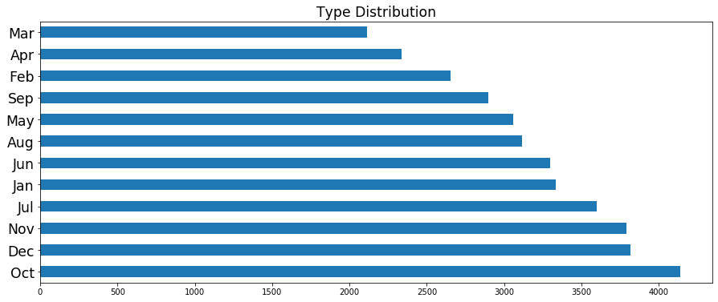

```python
df1['month'].value_counts().plot(kind = 'barh',figsize = (15,6))

plt.yticks(fontsize = 'xx-large')
plt.title('Type Distribution', fontsize = 'xx-large')
```

time

```python
df1['Time'] = df1['Time'].str.split(':').str.get(0)
```

```python
df1.head()
```

|  | AnimalType | Color | Name | OutcomeType | totalweeks | breed1 | Sex | sterilize1 | Time | month |
| --- | --- | --- | --- | --- | --- | --- | --- | --- | --- | --- |
| 0 | Dog | Brown | 1 | Return_to_owner | puppy | mix | Male | sterilized | 18 | Feb |
| 1 | Cat | Cream | 1 | Euthanasia | puppy | mix | Female | sterilized | 12 | Oct |
| 2 | Dog | Blue | 1 | Adoption | adult | bully | Male | sterilized | 12 | Jan |
| 3 | Cat | Blue | 0 | Transfer | puppy | mix | Male | not sterilized | 19 | Jul |
| 4 | Dog | Tan | 0 | Transfer | adult | pure | Male | sterilized | 12 | Nov |

```python
df1.Time = df1.Time.astype(int)
```

```python
def timeofday(x):
    if x >= 5 and x < 11:
        return 'morning'
    elif x >= 11 and x < 17:
        return 'afternoon'
    elif x >= 17 and x < 24:
        return 'evening'
    elif x >= 0 and x < 5:
        return 'night'
    else:
        return 'unknown'

df1['timeofday1'] = df1.Time.apply(timeofday)
```

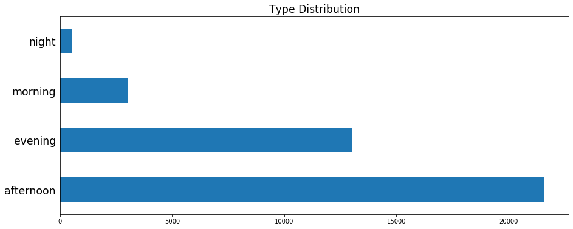

```python
df1['timeofday1'].value_counts().plot(kind = 'barh',figsize = (15,6))

plt.yticks(fontsize = 'xx-large')
plt.title('Type Distribution', fontsize = 'xx-large')
```

#### Dummy Variables

Since I am working with mainly categorical variables, I want to dummy them so they can be used properly in my model.

```python
del df1['Time']
```

```python
df1.head()
```

|  | AnimalType | Color | Name | OutcomeType | totalweeks | breed1 | Sex | sterilize1 | month | timeofday1 |
| --- | --- | --- | --- | --- | --- | --- | --- | --- | --- | --- |
| 0 | Dog | Brown | 1 | Return_to_owner | puppy | mix | Male | sterilized | Feb | evening |
| 1 | Cat | Cream | 1 | Euthanasia | puppy | mix | Female | sterilized | Oct | afternoon |
| 2 | Dog | Blue | 1 | Adoption | adult | bully | Male | sterilized | Jan | afternoon |
| 3 | Cat | Blue | 0 | Transfer | puppy | mix | Male | not sterilized | Jul | evening |
| 4 | Dog | Tan | 0 | Transfer | adult | pure | Male | sterilized | Nov | afternoon |

```python
df1 = pd.concat([df1, pd.get_dummies(df1['AnimalType'],prefix='type')], axis = 1)
df1 = pd.concat([df1, pd.get_dummies(df1['Color'],prefix = 'type')], axis = 1)
df1 = pd.concat([df1, pd.get_dummies(df1['totalweeks'],prefix='age')], axis = 1)
df1 = pd.concat([df1, pd.get_dummies(df1['breed1'],prefix='breed')], axis = 1)
df1 = pd.concat([df1, pd.get_dummies(df1['Sex'],prefix='sex')], axis = 1)
df1 = pd.concat([df1, pd.get_dummies(df1['sterilize1'],prefix='sterilize')], axis = 1)
df1 = pd.concat([df1, pd.get_dummies(df1['month'], prefix = 'month')], axis =1)
df1 = pd.concat([df1, pd.get_dummies(df1['timeofday1'], prefix = 'time')], axis = 1)
```

```python
print(df1.columns.values)
```

```
['AnimalType' 'Color' 'Name' 'OutcomeType' 'totalweeks' 'breed1' 'Sex'
 'sterilize1' 'month' 'timeofday1' 'type_Cat' 'type_Dog' 'type_Agouti'
 'type_Apricot' 'type_Black' 'type_Blue' 'type_Brown' 'type_Buff'
 'type_Calico' 'type_Chocolate' 'type_Cream' 'type_Fawn' 'type_Flame'
 'type_Gold' 'type_Gray' 'type_Lilac' 'type_Liver' 'type_Lynx'
 'type_Orange' 'type_Pink' 'type_Red' 'type_Ruddy' 'type_Sable'
 'type_Seal' 'type_Silver' 'type_Tan' 'type_Torbie' 'type_Tortie'
 'type_Tricolor' 'type_White' 'type_Yellow' 'age_adult' 'age_puppy'
 'breed_bully' 'breed_mix' 'breed_pure' 'sex_Female' 'sex_Male'
 'sterilize_not sterilized' 'sterilize_sterilized' 'month_Apr' 'month_Aug'
 'month_Dec' 'month_Feb' 'month_Jan' 'month_Jul' 'month_Jun' 'month_Mar'
 'month_May' 'month_Nov' 'month_Oct' 'month_Sep' 'time_afternoon'
 'time_evening' 'time_morning' 'time_night']
```

I am going to eliminate any of the columns that were dummied, as well as any columns I wound up not using.

```python
del df1['Color']
del df1['AnimalType']
del df1['totalweeks']
del df1['breed1']
del df1['Sex']
del df1['sterilize1']
del df1['timeofday1']
del df1['month']
```

```python
df1.head()
```

|  | Name | OutcomeType | type_Cat | type_Dog | type_Agouti | type_Apricot | type_Black | type_Blue | type_Brown | type_Buff | ... | month_Jun | month_Mar | month_May | month_Nov | month_Oct | month_Sep | time_afternoon | time_evening | time_morning | time_night |
| --- | --- | --- | --- | --- | --- | --- | --- | --- | --- | --- | --- | --- | --- | --- | --- | --- | --- | --- | --- | --- | --- |
| 0 | 1 | Return_to_owner | 0 | 1 | 0 | 0 | 0 | 0 | 1 | 0 | ... | 0 | 0 | 0 | 0 | 0 | 0 | 0 | 1 | 0 | 0 |
| 1 | 1 | Euthanasia | 1 | 0 | 0 | 0 | 0 | 0 | 0 | 0 | ... | 0 | 0 | 0 | 0 | 1 | 0 | 1 | 0 | 0 | 0 |
| 2 | 1 | Adoption | 0 | 1 | 0 | 0 | 0 | 1 | 0 | 0 | ... | 0 | 0 | 0 | 0 | 0 | 0 | 1 | 0 | 0 | 0 |
| 3 | 0 | Transfer | 1 | 0 | 0 | 0 | 0 | 1 | 0 | 0 | ... | 0 | 0 | 0 | 0 | 0 | 0 | 0 | 1 | 0 | 0 |
| 4 | 0 | Transfer | 0 | 1 | 0 | 0 | 0 | 0 | 0 | 0 | ... | 0 | 0 | 0 | 1 | 0 | 0 | 1 | 0 | 0 | 0 |

5 rows × 58 columns

#### Move Target Variable (Outcome)

```python
targetName = 'OutcomeType'
targetSeries = df1[targetName]
del df1[targetName]
df1.insert(0, targetName, targetSeries)

df1.tail()
```

|  | OutcomeType | Name | type_Cat | type_Dog | type_Agouti | type_Apricot | type_Black | type_Blue | type_Brown | type_Buff | ... | month_Jun | month_Mar | month_May | month_Nov | month_Oct | month_Sep | time_afternoon | time_evening | time_morning | time_night |
| --- | --- | --- | --- | --- | --- | --- | --- | --- | --- | --- | --- | --- | --- | --- | --- | --- | --- | --- | --- | --- | --- |
| 11451 |  | 0 | 1 | 0 | 0 | 0 | 1 | 0 | 0 | 0 | ... | 0 | 0 | 0 | 0 | 0 | 0 | 1 | 0 | 0 | 0 |
| 11452 |  | 0 | 1 | 0 | 0 | 0 | 0 | 1 | 0 | 0 | ... | 0 | 0 | 0 | 0 | 1 | 0 | 1 | 0 | 0 | 0 |
| 11453 |  | 0 | 1 | 0 | 0 | 0 | 0 | 0 | 0 | 0 | ... | 0 | 0 | 0 | 0 | 0 | 1 | 0 | 0 | 1 | 0 |
| 11454 |  | 1 | 0 | 1 | 0 | 0 | 1 | 0 | 0 | 0 | ... | 0 | 0 | 0 | 0 | 0 | 1 | 0 | 1 | 0 | 0 |
| 11455 |  | 1 | 0 | 1 | 0 | 0 | 0 | 0 | 0 | 0 | ... | 0 | 0 | 0 | 0 | 0 | 0 | 0 | 1 | 0 | 0 |

5 rows × 58 columns

#### Split training and test data

Now that I've finished pre-processing the data, I am going to split my data back out to how they originally came and then split the training data into training/test sets.

```python
print(df1.shape)

df_test =  df1[df1['OutcomeType']=='']
df1 = df1[df1['OutcomeType']!='']

print(df_test.shape)
print(df1.shape)
```

```
(38160, 58)
(11450, 58)
(26710, 58)
```

```python
del df_test['OutcomeType']
df_test.head()
```

|  | Name | type_Cat | type_Dog | type_Agouti | type_Apricot | type_Black | type_Blue | type_Brown | type_Buff | type_Calico | ... | month_Jun | month_Mar | month_May | month_Nov | month_Oct | month_Sep | time_afternoon | time_evening | time_morning | time_night |
| --- | --- | --- | --- | --- | --- | --- | --- | --- | --- | --- | --- | --- | --- | --- | --- | --- | --- | --- | --- | --- | --- |
| 0 | 1 | 0 | 1 | 0 | 0 | 0 | 0 | 0 | 0 | 0 | ... | 0 | 0 | 0 | 0 | 1 | 0 | 1 | 0 | 0 | 0 |
| 1 | 1 | 0 | 1 | 0 | 0 | 1 | 0 | 0 | 0 | 0 | ... | 0 | 0 | 0 | 0 | 0 | 0 | 0 | 1 | 0 | 0 |
| 2 | 1 | 1 | 0 | 0 | 0 | 0 | 0 | 1 | 0 | 0 | ... | 0 | 0 | 0 | 0 | 0 | 0 | 1 | 0 | 0 | 0 |
| 3 | 1 | 0 | 1 | 0 | 0 | 0 | 0 | 0 | 0 | 0 | ... | 0 | 0 | 0 | 0 | 0 | 0 | 0 | 1 | 0 | 0 |
| 4 | 1 | 0 | 1 | 0 | 0 | 0 | 0 | 0 | 0 | 0 | ... | 0 | 0 | 0 | 0 | 0 | 1 | 0 | 1 | 0 | 0 |

5 rows × 57 columns

I am going to do a 70/30 split.

```python
features_train, features_test, target_train, target_test = train_test_split(
    df1.ix[:,1:].values, df1.ix[:,0].values, test_size=0.30, random_state=0)

print(features_train.shape)
print(features_test.shape)
print(target_train.shape)
print(target_test.shape)
print(df1.shape)
```

```
(18697, 57)
(8013, 57)
(18697,)
(8013,)
(26710, 58)
```

#### Import necessary sklearn libraries:

```python
from sklearn.metrics import accuracy_score, precision_score, recall_score, f1_score
from sklearn.metrics import roc_curve, auc, confusion_matrix, classification_report
from sklearn.tree import DecisionTreeClassifier
from sklearn import tree
```

#### Basic Decision Tree

I want to run a basic decision tree model to see what I'm working with.

```python
cl_dt = tree.DecisionTreeClassifier()

print(cl_dt) # Printing this shows the defaults for the decision tree and the paramters I can tune.

cl_dt = cl_dt.fit(features_train, target_train)
target_predicted_dt = cl_dt.predict(features_test)
```

```
DecisionTreeClassifier(ccp_alpha=0.0, class_weight=None, criterion='gini',
                       max_depth=None, max_features=None, max_leaf_nodes=None,
                       min_impurity_decrease=0.0, min_impurity_split=None,
                       min_samples_leaf=1, min_samples_split=2,
                       min_weight_fraction_leaf=0.0, presort='deprecated',
                       random_state=None, splitter='best')
```

```python
print("DT Accuracy Score", accuracy_score(target_test, target_predicted_dt))
print('')
target_names=['Adopted','Passed','Euthanized','Returned To Owner','Transferred']
print('Classification Report:')
print(classification_report(target_test, target_predicted_dt, target_names = target_names))
print('')
print("Confusion Matrix:")
print(confusion_matrix(target_test, target_predicted_dt))

target_predicted_dt
```

```
DT Accuracy Score 0.5891676026457008

Classification Report:
                   precision    recall  f1-score   support

          Adopted       0.64      0.75      0.69      3271
           Passed       0.07      0.08      0.08        49
       Euthanized       0.24      0.21      0.23       464
Returned To Owner       0.38      0.35      0.37      1401
      Transferred       0.69      0.59      0.64      2828

         accuracy                           0.59      8013
        macro avg       0.41      0.40      0.40      8013
     weighted avg       0.59      0.59      0.58      8013


Confusion Matrix:
[[2462    6   55  434  314]
 [   5    4    6    5   29]
 [  72    8   98   84  202]
 [ 660    3   59  491  188]
 [ 676   33  187  266 1666]]
```

```
array(['Transfer', 'Return_to_owner', 'Adoption', ..., 'Return_to_owner',
       'Transfer', 'Adoption'], dtype=object)
```

The accuracy isn't great, but what really catches my eye is the horrendous precision and recall for majority of the variables. The precision and recall for "Adopted" isn't too bad, but this was also the most frequently occuring "outcome" within the dataset. I am going to have to find a way to balance my data because this will likely affect any model I try.

#### Cross Validation

```python
cv_dt = cross_val_score(cl_dt,features_train,target_train,cv=5)
print('Cross Validation Scores',cv_dt)
cv_dt.mean()
```

```
Cross Validation Scores [0.58449198 0.58395722 0.5950789  0.58224124 0.57341535]
```

```
0.5838369377267794
```

The cross validation scores for this model do vary slightly, but I don't think this model is at a high risk of overfitting.

#### Logistic Regression

```python
from sklearn.linear_model import LogisticRegression
cl_lr = LogisticRegression(max_iter = 200)

cl_lr.fit(features_train, target_train)
predicted_cl_lr = cl_lr.predict(features_test)
expected = target_test
print("Logistic Regression", accuracy_score(expected,predicted_cl_lr))
print(classification_report(expected, predicted_cl_lr))
print(confusion_matrix(expected, predicted_cl_lr))
```

```
Logistic Regression 0.63584175714464
                 precision    recall  f1-score   support

       Adoption       0.67      0.77      0.71      3271
           Died       0.00      0.00      0.00        49
     Euthanasia       0.35      0.05      0.09       464
Return_to_owner       0.42      0.48      0.45      1401
       Transfer       0.73      0.67      0.70      2828

       accuracy                           0.64      8013
      macro avg       0.43      0.39      0.39      8013
   weighted avg       0.62      0.64      0.62      8013

[[2507    0    1  556  207]
 [   5    0    0    3   41]
 [  67    0   23   88  286]
 [ 543    0   14  672  172]
 [ 633    0   28  274 1893]]
```

#### Cross Validation

```python
cv_log1 = cross_val_score(cl_lr,features_train,target_train,cv=5)
print('Cross Validation Scores',cv_log1)
cv_log1.mean()
```

```
Cross Validation Scores [0.6459893  0.63957219 0.64215031 0.63733619 0.63412677]
```

```
0.6398349525810471
```

This model doesn't seem to be at a high risk for overfitting. But, the precision and recall are horrible. I want to utilize SMOTE, but this can lead to overfitting. I know I have a lot of variables within my data, which also concerns me, so I am going to utilize Recursive Feature Elimination first to identify which variables have the most predictive power.

#### Recursive Feature Elimination

```python
from sklearn.feature_selection import RFE

rfe = RFE(cl_lr, 20)
rfe = rfe.fit(features_train, target_train)
print(rfe.support_)
print(rfe.ranking_)
print(df1.columns)
```

```
[ True  True False  True  True False False False False False False  True
 False  True  True False False False False False False False False  True
 False  True False False False  True False False  True  True  True False
 False  True  True  True  True False False False False False False False
 False False False False False False  True  True  True]
[ 1  1  5  1  1 26 34 24 10 20  3  1 11  1  1 14  6  2  7 35 37 25 38  1
 12  1 22 27  9  1 23 13  1  1  1 19 18  1  1  1  1  8 17 16 33 36 21 31
 29 32 30 28 15  4  1  1  1]
Index(['OutcomeType', 'Name', 'type_Cat', 'type_Dog', 'type_Agouti',
       'type_Apricot', 'type_Black', 'type_Blue', 'type_Brown', 'type_Buff',
       'type_Calico', 'type_Chocolate', 'type_Cream', 'type_Fawn',
       'type_Flame', 'type_Gold', 'type_Gray', 'type_Lilac', 'type_Liver',
       'type_Lynx', 'type_Orange', 'type_Pink', 'type_Red', 'type_Ruddy',
       'type_Sable', 'type_Seal', 'type_Silver', 'type_Tan', 'type_Torbie',
       'type_Tortie', 'type_Tricolor', 'type_White', 'type_Yellow',
       'age_adult', 'age_puppy', 'breed_bully', 'breed_mix', 'breed_pure',
       'sex_Female', 'sex_Male', 'sterilize_not sterilized',
       'sterilize_sterilized', 'month_Apr', 'month_Aug', 'month_Dec',
       'month_Feb', 'month_Jan', 'month_Jul', 'month_Jun', 'month_Mar',
       'month_May', 'month_Nov', 'month_Oct', 'month_Sep', 'time_afternoon',
       'time_evening', 'time_morning', 'time_night'],
      dtype='object')
```

The RFE aids in selecting which features contribute to the prediction of the target variable (identified by "TRUE"). I want to create a new dataframe with the features that the RFE identified as valuable. I will do that below.

```python
df2 = df1[['OutcomeType','Name','type_Cat', 'type_Agouti','type_Apricot','type_Cream','type_Flame','type_Gold',
          'type_Sable','type_Silver','type_Tricolor','age_adult','age_puppy','breed_bully','sex_Female',
          'sex_Male','sterilize_not sterilized','sterilize_sterilized','time_evening','time_morning','time_night']].copy()
```

Create new train/test set with reduced features.

```python
features_train2, features_test2, target_train2, target_test2 = train_test_split(
    df2.ix[:,1:].values, df2.ix[:,0].values, test_size=0.30, random_state=0)

print(features_train2.shape)
print(features_test2.shape)
print(target_train2.shape)
print(target_test2.shape)
print(df2.shape)
```

```
(18697, 20)
(8013, 20)
(18697,)
(8013,)
(26710, 21)
```

#### 2nd Logistic Regression

I want to run a logistic regression again to see if the reduced features helps with my model.

```python
from sklearn.linear_model import LogisticRegression
cl_lr1 = LogisticRegression(max_iter = 200)

cl_lr1.fit(features_train2, target_train2)
predicted_cl_lr1 = cl_lr1.predict(features_test2)
expected1 = target_test2
print("Logistic Regression", accuracy_score(expected1,predicted_cl_lr1))
print(classification_report(expected1, predicted_cl_lr1))
print(confusion_matrix(expected1, predicted_cl_lr1))
```

```
Logistic Regression 0.6429551978035692
                 precision    recall  f1-score   support

       Adoption       0.68      0.78      0.72      3271
           Died       0.00      0.00      0.00        49
     Euthanasia       0.40      0.04      0.07       464
Return_to_owner       0.43      0.52      0.47      1401
       Transfer       0.74      0.66      0.70      2828

       accuracy                           0.64      8013
      macro avg       0.45      0.40      0.39      8013
   weighted avg       0.64      0.64      0.63      8013

[[2541    0    1  587  142]
 [   5    0    0    3   41]
 [  70    0   18   87  289]
 [ 482    0   12  731  176]
 [ 662    0   14  290 1862]]
```

#### Cross Validation

```python
cv_log2 = cross_val_score(cl_lr1,features_train2,target_train2,cv=5)
print('Cross Validation Scores',cv_log2)
cv_log2.mean()
```

```
Cross Validation Scores [0.64304813 0.64064171 0.6410805  0.63813854 0.63118481]
```

```
0.6388187381738661
```

The feature selection didn't really help my accuracy or precision/recall, which supports my belief that I have to balance my data. I'm going to try to SMOTE the data and see if it helps. I'll go ahead and do it on both dataframes just to see the differences between the two. Since SMOTE is an oversampling technique, I do fear that it can lead to overfitting; I'm thinking the reduced features will help mitigate that.

#### SMOTE

SMOTE on original test/train set.

```python
from imblearn.over_sampling import SMOTE

smt = SMOTE()
features_train_smt, target_train_smt = smt.fit_sample(features_train, target_train)
```

```python
from sklearn.linear_model import LogisticRegression
cl_lr = LogisticRegression(max_iter = 200)

cl_lr.fit(features_train_smt, target_train_smt)
predicted_cl_lr = cl_lr.predict(features_test)
expected = target_test
print("Logistic Regression", accuracy_score(expected,predicted_cl_lr))
print(classification_report(expected, predicted_cl_lr))
print(confusion_matrix(expected, predicted_cl_lr))
```

```
Logistic Regression 0.6228628478722077
                 precision    recall  f1-score   support

       Adoption       0.68      0.73      0.71      3271
           Died       0.10      0.06      0.07        49
     Euthanasia       0.28      0.16      0.21       464
Return_to_owner       0.42      0.59      0.49      1401
       Transfer       0.75      0.60      0.67      2828

       accuracy                           0.62      8013
      macro avg       0.45      0.43      0.43      8013
   weighted avg       0.63      0.62      0.62      8013

[[2382    0    9  682  198]
 [   3    3    3    3   37]
 [  54    1   76  105  228]
 [ 433    0   24  823  121]
 [ 608   27  155  331 1707]]
```

```python
cv_log = cross_val_score(cl_lr,features_train_smt,target_train_smt,cv=5)
print('Cross Validation Scores',cv_log)
cv_log.mean()
```

```
Cross Validation Scores [0.58308882 0.66644439 0.70232062 0.68671646 0.67497999]
```

```
0.6627100560149373
```

The logistic regression with the data after SMOTE did improve the precision/recall without the accuracy taking a huge blow. But, wow is this data horribly overfit. I want to see if using SMOTE on the dataset with reduced features performs better; I can't use a model knowing that the cross validation scores vary from 0.58 to 0.70.

SMOTE on reduced data:

```python
from imblearn.over_sampling import SMOTE

smt = SMOTE()
features_train_smt2, target_train_smt2 = smt.fit_sample(features_train2, target_train2)
```

```python
from sklearn.linear_model import LogisticRegression
cl_lr1 = LogisticRegression(max_iter = 200)

cl_lr1.fit(features_train_smt2, target_train_smt2)
predicted_cl_lr1 = cl_lr1.predict(features_test2)
expected1 = target_test2
print("Logistic Regression", accuracy_score(expected1,predicted_cl_lr1))
print(classification_report(expected1, predicted_cl_lr1))
print(confusion_matrix(expected1, predicted_cl_lr1))
```

```
Logistic Regression 0.5074254336702858
                 precision    recall  f1-score   support

       Adoption       0.70      0.69      0.70      3271
           Died       0.03      0.51      0.05        49
     Euthanasia       0.19      0.44      0.27       464
Return_to_owner       0.42      0.58      0.49      1401
       Transfer       0.81      0.27      0.40      2828

       accuracy                           0.51      8013
      macro avg       0.43      0.50      0.38      8013
   weighted avg       0.66      0.51      0.53      8013

[[2267   45  166  720   73]
 [   3   25   11    3    7]
 [  34   70  202   89   69]
 [ 355   28  181  812   25]
 [ 559  702  489  318  760]]
```

```python
cv_log2 = cross_val_score(cl_lr1,features_train_smt2,target_train_smt2,cv=5)
print('Cross Validation Scores',cv_log2)
cv_log2.mean()
```

```
Cross Validation Scores [0.51053614 0.52227261 0.51947186 0.5201387  0.5257402 ]
```

```
0.5196319018404909
```

I want to run a grid search to see if I can tune the logistic regression I ran previously.

```python
print(cl_lr1)
```

```
LogisticRegression(C=1.0, class_weight=None, dual=False, fit_intercept=True,
                   intercept_scaling=1, l1_ratio=None, max_iter=200,
                   multi_class='auto', n_jobs=None, penalty='l2',
                   random_state=None, solver='lbfgs', tol=0.0001, verbose=0,
                   warm_start=False)
```

```python
from sklearn.model_selection import GridSearchCV

# define parameters
parameters = {'max_iter':[50,100,150,200,250],
             'penalty':['l1', 'l2']}

# run first grid search
grid_lr = GridSearchCV(cl_lr1, parameters,n_jobs=-1, cv=5)
grid_lr = grid_lr.fit(features_train_smt2, target_train_smt2)
#print("Scores:", grid_rfg.cv_results_) # commented out for length
print("Best score:", grid_lr.best_score_)
print("Best parameter:", grid_lr.best_params_)
```

```
Best score: 0.5197919445185384
Best parameter: {'max_iter': 150, 'penalty': 'l2'}
```

```python
from sklearn.model_selection import GridSearchCV

# define parameters
parameters = {'max_iter':[125,130,150,160,175],
             'penalty':['l1', 'l2']}

# run first grid search
grid_lr = GridSearchCV(cl_lr1, parameters,n_jobs=-1, cv=5)
grid_lr = grid_lr.fit(features_train_smt2, target_train_smt2)
#print("Scores:", grid_rfg.cv_results_) # commented out for length
print("Best score:", grid_lr.best_score_)
print("Best parameter:", grid_lr.best_params_)
```

```
Best score: 0.5197919445185384
Best parameter: {'max_iter': 150, 'penalty': 'l2'}
```

```python
from sklearn.model_selection import GridSearchCV

# define parameters
parameters = {'max_iter':[140,145,150,155,160],
             'penalty':['l1', 'l2']}

# run first grid search
grid_lr = GridSearchCV(cl_lr1, parameters,n_jobs=-1, cv=5)
grid_lr = grid_lr.fit(features_train_smt2, target_train_smt2)
#print("Scores:", grid_rfg.cv_results_) # commented out for length
print("Best score:", grid_lr.best_score_)
print("Best parameter:", grid_lr.best_params_)
```

```
Best score: 0.5198452920778875
Best parameter: {'max_iter': 155, 'penalty': 'l2'}
```

```python
from sklearn.linear_model import LogisticRegression
cl_lr2 = LogisticRegression(max_iter = 155, penalty = 'l2')

cl_lr2.fit(features_train_smt2, target_train_smt2)
predicted_cl_lr2 = cl_lr2.predict(features_test2)
expected1 = target_test2
print("Logistic Regression", accuracy_score(expected1,predicted_cl_lr2))
print(classification_report(expected1, predicted_cl_lr2))
print(confusion_matrix(expected1, predicted_cl_lr2))
```

```
Logistic Regression 0.5074254336702858
                 precision    recall  f1-score   support

       Adoption       0.70      0.69      0.70      3271
           Died       0.03      0.51      0.05        49
     Euthanasia       0.19      0.44      0.27       464
Return_to_owner       0.42      0.58      0.49      1401
       Transfer       0.81      0.27      0.40      2828

       accuracy                           0.51      8013
      macro avg       0.43      0.50      0.38      8013
   weighted avg       0.66      0.51      0.53      8013

[[2267   45  166  720   73]
 [   3   25   11    3    7]
 [  34   70  202   89   69]
 [ 355   28  181  812   25]
 [ 559  702  489  318  760]]
```

The grid search provided almost identical results.

```python
cv_log3 = cross_val_score(cl_lr2,features_train_smt2,target_train_smt2,cv=5)
print('Cross Validation Scores',cv_log3)
cv_log3.mean()
```

```
Cross Validation Scores [0.51053614 0.52240597 0.51947186 0.5201387  0.52640704]
```

```
0.5197919445185383
```

On the bright side, at least the model isn't overfit.

#### Random Forest

```python
from sklearn.ensemble import RandomForestClassifier
rf0 = RandomForestClassifier()
print(rf0)
rf0.fit(features_train_smt2, target_train_smt2)
target_pred_rf = rf0.predict(features_test2)

print(accuracy_score(target_test2, target_pred_rf))
target_names = ['Adopted','Passed','Euthanized','Returned To Owner','Transferred']
print(classification_report(target_test2, target_pred_rf, target_names=target_names))
print('')
print("Confusion Matrix")
print(confusion_matrix(target_test2, target_pred_rf))
```

```
RandomForestClassifier(bootstrap=True, ccp_alpha=0.0, class_weight=None,
                       criterion='gini', max_depth=None, max_features='auto',
                       max_leaf_nodes=None, max_samples=None,
                       min_impurity_decrease=0.0, min_impurity_split=None,
                       min_samples_leaf=1, min_samples_split=2,
                       min_weight_fraction_leaf=0.0, n_estimators=100,
                       n_jobs=None, oob_score=False, random_state=None,
                       verbose=0, warm_start=False)
0.49831523773867464
                   precision    recall  f1-score   support

          Adopted       0.74      0.64      0.69      3271
           Passed       0.02      0.49      0.04        49
       Euthanized       0.20      0.35      0.26       464
Returned To Owner       0.40      0.58      0.47      1401
      Transferred       0.71      0.31      0.43      2828

         accuracy                           0.50      8013
        macro avg       0.42      0.48      0.38      8013
     weighted avg       0.63      0.50      0.53      8013


Confusion Matrix
[[2107   84  145  761  174]
 [   2   24    8    3   12]
 [  17  110  161   92   84]
 [ 291   18  187  819   86]
 [ 438  842  291  375  882]]
```

```python
from sklearn.model_selection import GridSearchCV

# define parameters
parameters = {'n_estimators':[50,100,150,200,250],
             'max_depth':[1,10,20,50,100],
             'criterion':['gini','entropy']}

# run first grid search
grid_rfg = GridSearchCV(rf0, parameters,n_jobs=-1, cv=5)
grid_rfg = grid_rfg.fit(features_train_smt2, target_train_smt2)
#print("Scores:", grid_rfg.cv_results_) # commented out for length
print("Best score:", grid_rfg.best_score_)
print("Best parameter:", grid_rfg.best_params_)
```

```
Best score: 0.5650040010669513
Best parameter: {'criterion': 'entropy', 'max_depth': 100, 'n_estimators': 200}
```

```python
cl_rf = RandomForestClassifier(criterion='entropy', n_estimators=200, max_depth=100)
cl_rf.fit(features_train_smt2, target_train_smt2)
target_pred_rf = cl_rf.predict(features_test2)
print(cl_rf)

print(accuracy_score(target_test2, target_pred_rf))
target_names = ['Adopted','Passed','Euthanized','Returned To Owner','Transferred']
print(classification_report(target_test2, target_pred_rf, target_names=target_names))
print('')
print("Confusion Matrix")
print(confusion_matrix(target_test2, target_pred_rf))
```

```
RandomForestClassifier(bootstrap=True, ccp_alpha=0.0, class_weight=None,
                       criterion='entropy', max_depth=100, max_features='auto',
                       max_leaf_nodes=None, max_samples=None,
                       min_impurity_decrease=0.0, min_impurity_split=None,
                       min_samples_leaf=1, min_samples_split=2,
                       min_weight_fraction_leaf=0.0, n_estimators=200,
                       n_jobs=None, oob_score=False, random_state=None,
                       verbose=0, warm_start=False)
0.5016847622613253
                   precision    recall  f1-score   support

          Adopted       0.74      0.64      0.69      3271
           Passed       0.02      0.49      0.04        49
       Euthanized       0.22      0.33      0.26       464
Returned To Owner       0.40      0.61      0.48      1401
      Transferred       0.71      0.31      0.43      2828

         accuracy                           0.50      8013
        macro avg       0.42      0.48      0.38      8013
     weighted avg       0.63      0.50      0.53      8013


Confusion Matrix
[[2106   84  110  796  175]
 [   2   24    8    3   12]
 [  17  109  151  101   86]
 [ 285   18  153  856   89]
 [ 439  840  271  395  883]]
```

```python
cv_rf = cross_val_score(cl_rf,features_train_smt2,target_train_smt2,cv=5)
print('Cross Validation Scores',cv_rf)
cv_rf.mean()
```

```
Cross Validation Scores [0.55321419 0.57095225 0.56201654 0.57321953 0.56415044]
```

```
0.5647105894905307
```

This Random Forest model is not-so-great. The accuracy is in the low 50's and the precision and recall are all over the place. However, it does not appear to be at risk for overfitting.

I want to try the original SMOTE-ed data to see if it was just the model I was using that led to overfitting and if Random Forest has any better impact.

```python
cl_rf = RandomForestClassifier(criterion='entropy', n_estimators=250, max_depth=100)
cl_rf.fit(features_train_smt, target_train_smt)
target_pred_rf = cl_rf.predict(features_test)
print(cl_rf)

print(accuracy_score(target_test, target_pred_rf))
target_names = ['Adopted','Passed','Euthanized','Returned To Owner','Transferred']
print(classification_report(target_test, target_pred_rf, target_names=target_names))
print('')
print("Confusion Matrix")
print(confusion_matrix(target_test, target_pred_rf))
```

```
RandomForestClassifier(bootstrap=True, ccp_alpha=0.0, class_weight=None,
                       criterion='entropy', max_depth=100, max_features='auto',
                       max_leaf_nodes=None, max_samples=None,
                       min_impurity_decrease=0.0, min_impurity_split=None,
                       min_samples_leaf=1, min_samples_split=2,
                       min_weight_fraction_leaf=0.0, n_estimators=250,
                       n_jobs=None, oob_score=False, random_state=None,
                       verbose=0, warm_start=False)
0.5396231124422813
                   precision    recall  f1-score   support

          Adopted       0.72      0.65      0.68      3271
           Passed       0.03      0.27      0.05        49
       Euthanized       0.22      0.31      0.26       464
Returned To Owner       0.38      0.61      0.47      1401
      Transferred       0.70      0.43      0.53      2828

         accuracy                           0.54      8013
        macro avg       0.41      0.45      0.40      8013
     weighted avg       0.62      0.54      0.56      8013


Confusion Matrix
[[2113   13   94  801  250]
 [   3   13   10    3   20]
 [  26   47  146  112  133]
 [ 317    7  107  849  121]
 [ 473  404  304  444 1203]]
```

```python
# I am going to run with cv = 10 to be sure since this has a history of being overfit.
cv_rf = cross_val_score(cl_rf,features_train_smt,target_train_smt,cv = 10)
print('Cross Validation Scores',cv_rf)
cv_rf.mean()
```

```
Cross Validation Scores [0.60789544 0.64843958 0.68284876 0.66417711 0.6711123  0.68631635
 0.67591358 0.67831422 0.65804214 0.68364897]
```

```
0.6656708455588157
```

This still shows signs of overfitting. The one thing I noticed through the feature reduction was that "month" didn't have a single value that was deemed significant. I'm going to remove that from the df1 (all other features included) dataframe and see if that helps. If not, I will have to settle for df2, which is the one with feature reduction and SMOTE. The accuracy is worse, but again, I would rather have a non-overfit model.

```python
df1.columns
```

```
Index(['OutcomeType', 'Name', 'type_Cat', 'type_Dog', 'type_Agouti',
       'type_Apricot', 'type_Black', 'type_Blue', 'type_Brown', 'type_Buff',
       'type_Calico', 'type_Chocolate', 'type_Cream', 'type_Fawn',
       'type_Flame', 'type_Gold', 'type_Gray', 'type_Lilac', 'type_Liver',
       'type_Lynx', 'type_Orange', 'type_Pink', 'type_Red', 'type_Ruddy',
       'type_Sable', 'type_Seal', 'type_Silver', 'type_Tan', 'type_Torbie',
       'type_Tortie', 'type_Tricolor', 'type_White', 'type_Yellow',
       'age_adult', 'age_puppy', 'breed_bully', 'breed_mix', 'breed_pure',
       'sex_Female', 'sex_Male', 'sterilize_not sterilized',
       'sterilize_sterilized', 'month_Apr', 'month_Aug', 'month_Dec',
       'month_Feb', 'month_Jan', 'month_Jul', 'month_Jun', 'month_Mar',
       'month_May', 'month_Nov', 'month_Oct', 'month_Sep', 'time_afternoon',
       'time_evening', 'time_morning', 'time_night'],
      dtype='object')
```

```python
del df1['month_Apr']
del df1['month_Aug']
del df1['month_Dec']
del df1['month_Feb']
del df1['month_Jan']
del df1['month_Jul']
del df1['month_Jun']
del df1['month_Mar']
del df1['month_May']
del df1['month_Nov']
del df1['month_Oct']
del df1['month_Sep']
```

One last try!

Re-split and SMOTE data

```python
features_train, features_test, target_train, target_test = train_test_split(
    df1.ix[:,1:].values, df1.ix[:,0].values, test_size=0.30, random_state=0)

print(features_train.shape)
print(features_test.shape)
print(target_train.shape)
print(target_test.shape)
print(df1.shape)
```

```
(18697, 45)
(8013, 45)
(18697,)
(8013,)
(26710, 46)
```

```python
from imblearn.over_sampling import SMOTE

smt = SMOTE()
features_train_smt, target_train_smt = smt.fit_sample(features_train, target_train)
```

```python
cl_rf = RandomForestClassifier(criterion='entropy', n_estimators=250, max_depth=100)
cl_rf.fit(features_train_smt, target_train_smt)
target_pred_rf = cl_rf.predict(features_test)
print(cl_rf)

print(accuracy_score(target_test, target_pred_rf))
target_names = ['Adopted','Passed','Euthanized','Returned To Owner','Transferred']
print(classification_report(target_test, target_pred_rf, target_names=target_names))
print('')
print("Confusion Matrix")
print(confusion_matrix(target_test, target_pred_rf))
```

```
RandomForestClassifier(bootstrap=True, ccp_alpha=0.0, class_weight=None,
                       criterion='entropy', max_depth=100, max_features='auto',
                       max_leaf_nodes=None, max_samples=None,
                       min_impurity_decrease=0.0, min_impurity_split=None,
                       min_samples_leaf=1, min_samples_split=2,
                       min_weight_fraction_leaf=0.0, n_estimators=250,
                       n_jobs=None, oob_score=False, random_state=None,
                       verbose=0, warm_start=False)
0.5409958816922501
                   precision    recall  f1-score   support

          Adopted       0.72      0.65      0.68      3271
           Passed       0.03      0.27      0.05        49
       Euthanized       0.23      0.31      0.26       464
Returned To Owner       0.38      0.61      0.47      1401
      Transferred       0.70      0.43      0.53      2828

         accuracy                           0.54      8013
        macro avg       0.41      0.45      0.40      8013
     weighted avg       0.62      0.54      0.56      8013


Confusion Matrix
[[2119   13   90  796  253]
 [   3   13   10    4   19]
 [  26   47  146  111  134]
 [ 320    7  104  848  122]
 [ 475  400  298  446 1209]]
```

```python
cv_rf = cross_val_score(cl_rf,features_train_smt,target_train_smt,cv=10)
print('Cross Validation Scores',cv_rf)
cv_rf.mean()
```

```
Cross Validation Scores [0.60789544 0.6492398  0.68258202 0.66524407 0.67271272 0.68578288
 0.67804748 0.67671379 0.65777541 0.6831155 ]
```

```
0.665910909575887
```

Well, it was worth a shot but this model still appears to be at risk of overfitting. Back to df2!

#### KNN

```python
from sklearn.neighbors import KNeighborsClassifier
```

```python
cl_knn = KNeighborsClassifier(n_neighbors=3)
cl_knn.fit(features_train_smt2,target_train_smt2)
target_pred_knn = cl_knn.predict(features_test2)

print(cl_knn)

print('KNN=3 Accuracy Score:',accuracy_score(target_test2,target_pred_knn))
target_names=['Adopted','Passed','Euthanized','Returned To Owner','Transferred']
print('')
print('Classification Report:')
print(classification_report(target_test2,target_pred_knn,target_names=target_names))
print('')
print("Confusion Matrix:")
print(confusion_matrix(target_test2, target_pred_knn))
```

```
KNeighborsClassifier(algorithm='auto', leaf_size=30, metric='minkowski',
                     metric_params=None, n_jobs=None, n_neighbors=3, p=2,
                     weights='uniform')
KNN=3 Accuracy Score: 0.5951578684637464

Classification Report:
                   precision    recall  f1-score   support

          Adopted       0.62      0.81      0.70      3271
           Passed       0.09      0.02      0.03        49
       Euthanized       0.28      0.17      0.21       464
Returned To Owner       0.39      0.21      0.27      1401
      Transferred       0.65      0.62      0.63      2828

         accuracy                           0.60      8013
        macro avg       0.41      0.37      0.37      8013
     weighted avg       0.57      0.60      0.57      8013


Confusion Matrix:
[[2645    0   19  222  385]
 [   9    1    2    3   34]
 [  95    2   79   50  238]
 [ 742    1   61  289  308]
 [ 769    7  124  173 1755]]
```

```python
cv_knn = cross_val_score(cl_knn,features_train_smt2,target_train_smt2,cv = 5)
print('Cross Validation Scores for each K:',cv_knn)
cv_knn.mean()
```

```
Cross Validation Scores for each K: [0.39943985 0.41077621 0.40290744 0.39423846 0.39797279]
```

```
0.4010669511869832
```

The cross validation scores vary slightly, but not enough to cause concern.

```python
# define parameters
parameters = {'n_neighbors': [3,4,5,7,10]}

# run first grid search
grid_knn = GridSearchCV(cl_knn, parameters,n_jobs=-1, cv=5)
grid_knn = grid_knn.fit(features_train_smt2, target_train_smt2)
#print("Scores:", grid_rfg.cv_results_) # commented out for length
print("Best score:", grid_knn.best_score_)
print("Best parameter:", grid_knn.best_params_)
```

```
Best score: 0.41691117631368363
Best parameter: {'n_neighbors': 10}
```

```python
# define parameters
parameters = {'n_neighbors': [7,9,10,12,15]}

# run first grid search
grid_knn = GridSearchCV(cl_knn, parameters,n_jobs=-1, cv=5)
grid_knn = grid_knn.fit(features_train_smt2, target_train_smt2)
#print("Scores:", grid_rfg.cv_results_) # commented out for length
print("Best score:", grid_knn.best_score_)
print("Best parameter:", grid_knn.best_params_)
```

```
Best score: 0.43331555081355033
Best parameter: {'n_neighbors': 10}
```

```python
# define parameters
parameters = {'n_neighbors': [12,14,15,17,20]}

# run first grid search
grid_knn = GridSearchCV(cl_knn, parameters,n_jobs=-1, cv=5)
grid_knn = grid_knn.fit(features_train_smt2, target_train_smt2)
#print("Scores:", grid_rfg.cv_results_) # commented out for length
print("Best score:", grid_knn.best_score_)
print("Best parameter:", grid_knn.best_params_)
```

```
Best score: 0.43947719391837825
Best parameter: {'n_neighbors': 20}
```

```python
cl_knn = KNeighborsClassifier(n_neighbors=20)
cl_knn.fit(features_train_smt2,target_train_smt2)
target_pred_knn = cl_knn.predict(features_test2)

print(cl_knn)

print('KNN=3 Accuracy Score:',accuracy_score(target_test2,target_pred_knn))
target_names=['Adopted','Passed','Euthanized','Returned To Owner','Transferred']
print('')
print('Classification Report:')
print(classification_report(target_test2,target_pred_knn,target_names=target_names))
print('')
print("Confusion Matrix:")
print(confusion_matrix(target_test2, target_pred_knn))
```

```
KNeighborsClassifier(algorithm='auto', leaf_size=30, metric='minkowski',
                     metric_params=None, n_jobs=None, n_neighbors=20, p=2,
                     weights='uniform')
KNN=3 Accuracy Score: 0.6287283164857107

Classification Report:
                   precision    recall  f1-score   support

          Adopted       0.66      0.78      0.71      3271
           Passed       0.06      0.08      0.07        49
       Euthanized       0.41      0.16      0.23       464
Returned To Owner       0.41      0.52      0.46      1401
      Transferred       0.79      0.60      0.68      2828

         accuracy                           0.63      8013
        macro avg       0.46      0.43      0.43      8013
     weighted avg       0.64      0.63      0.63      8013


Confusion Matrix:
[[2536   15   16  587  117]
 [   5    4    2    3   35]
 [  62   12   74  112  204]
 [ 557    5   11  729   99]
 [ 668   33   79  353 1695]]
```

```python
cv_knn = cross_val_score(cl_knn,features_train_smt2,target_train_smt2,cv = 5)
print('Cross Validation Scores for each K:',cv_knn)
cv_knn.mean()
```

```
Cross Validation Scores for each K: [0.45598826 0.42851427 0.42277941 0.45692185 0.43318218]
```

```
0.43947719391837825
```

This KNN model is one of the best I've seen so far. That isn't saying too much as Adopted/Transferred returned decent precision and recall, unfortunately, it is still low for the rest of the categories. I am worried this is going to continue to be a constant issue due to the imbalance in the data.

#### Neural Net

Lastly, I want to try a Neural Network to see if this gives me any better results.

```python
from sklearn.neural_network import MLPClassifier

ann = MLPClassifier(activation='relu', alpha=1e-05, batch_size='auto',
       beta_1=0.9, beta_2=0.999, early_stopping=False,
       epsilon=1e-08, hidden_layer_sizes=(10,8), learning_rate='constant',
       learning_rate_init=0.001, max_iter=200, momentum=0.9,
       nesterovs_momentum=True, power_t=0.5, random_state=1, shuffle=True,
       solver='lbfgs', tol=0.0001, validation_fraction=0.1, verbose=False,
       warm_start=False)
ann.fit(features_train_smt2, target_train_smt2)

target_predicted_ann = ann.predict(features_test2)
print("Accuracy", accuracy_score(target_test2, target_predicted_ann))
target_names = ['Adopted','Passed','Euthanized','Returned To Owner','Transferred']
print(classification_report(target_test2, target_predicted_ann, target_names= target_names))
print(confusion_matrix(target_test2, target_predicted_ann))
```

```
Accuracy 0.5035567203294646
                   precision    recall  f1-score   support

          Adopted       0.71      0.67      0.69      3271
           Passed       0.02      0.49      0.05        49
       Euthanized       0.21      0.35      0.26       464
Returned To Owner       0.40      0.62      0.49      1401
      Transferred       0.79      0.28      0.41      2828

         accuracy                           0.50      8013
        macro avg       0.43      0.48      0.38      8013
     weighted avg       0.65      0.50      0.53      8013

[[2180  113  104  806   68]
 [   3   24    7    3   12]
 [  26   91  164  105   78]
 [ 324   20  127  870   60]
 [ 534  721  387  389  797]]
```

This was okay, pretty consistent with the previous models. I want to run an ensemble with this and KNN to see if it can help improve any of the accuracy metrics.

#### Cross Validation

```python
cv_ann = cross_val_score(ann,features_train_smt2,target_train_smt2,cv = 5)
print('Cross Validation Scores:',cv_ann)
cv_ann.mean()
```

```
Cross Validation Scores: [0.53454254 0.53627634 0.53640971 0.54454521 0.53294212]
```

```
0.5369431848492932
```

This model doesn't appear to be at risk for overfitting.

#### Ensemble Model

```python
from sklearn.ensemble import VotingClassifier

VOT = VotingClassifier(estimators=[('MLP', ann), ('KNN', cl_knn)])
```

```python
VOT.fit(features_train_smt2, target_train_smt2)
target_predicted_VOT = VOT.predict(features_test2)

#printing the confusion matrix and accuracy
print("VOT Accuracy Score", accuracy_score(target_test2, target_predicted_VOT))
print(classification_report(target_test2, target_predicted_VOT))
print(confusion_matrix(target_test2, target_predicted_VOT))
```

```
VOT Accuracy Score 0.5152876575564708
                 precision    recall  f1-score   support

       Adoption       0.66      0.78      0.72      3271
           Died       0.02      0.45      0.05        49
     Euthanasia       0.21      0.34      0.26       464
Return_to_owner       0.41      0.46      0.44      1401
       Transfer       0.81      0.27      0.40      2828

       accuracy                           0.52      8013
      macro avg       0.42      0.46      0.37      8013
   weighted avg       0.64      0.52      0.53      8013

[[2546   66   68  544   47]
 [   5   22    7    3   12]
 [  63   90  158   83   70]
 [ 559   18  124  647   53]
 [ 675  717  387  293  756]]
```

This is a little disappointing, I was expecting the ensemble model to perform a little better. While the precision/recall is in the same range of the other models, the accuracy is about 10% lower than the KNN model.

#### Model Selection

[figure not shown]

```python
%matplotlib inline
from IPython.display import Image
Image('model_compare3.png')
```

In conclusion, none of these models performed like I wanted them to. However, if I had to compare and choose, I would consider KNN to be the best. This dataset was especially difficult when it came to finding an ideal precision and recall without overfitting the data.

I tried to mitigate these issues through various techniques such as SMOTE and feature reduction. Unfortuantely, I was unable to achieve an acceptable model in terms of precision/recall. The precision and recall for two of the most common outcome categories, "Adopted" and "Transferred" were fairly decent, returning values in the 60's and 70's. The recall/precision for the animals that passed in the shelter is really where I struggled. I do believe this is due to the imbalance of many variable within the dataset and caused many of the issues I faced.

This was my first Kaggle competition and honestly, it was quite challenging. It pushed me to try things outside of what we learned in class and served as a great opportunity. Below, I will prepare and write to csv the submission data for the competition itself.

#### Prepare submission

```python
features_test2.shape
```

```
(8013, 20)
```

```python
# make sure df_test has the same columns as the training set
df_test2 = df_test[['Name','type_Cat', 'type_Agouti','type_Apricot','type_Cream','type_Flame','type_Gold',
          'type_Sable','type_Silver','type_Tricolor','age_adult','age_puppy','breed_bully','sex_Female',
          'sex_Male','sterilize_not sterilized','sterilize_sterilized','time_evening','time_morning','time_night']].copy()
```

```python
y_pred = cl_knn.predict_proba(df_test2)
```

```python
submit_df = pd.DataFrame(y_pred, columns = ['Adoption', 'Died', 'Euthanasia', 'Return_to_owner', 'Transfer'])
submit_df.head()

submit_df.insert(0, 'ID', df_ID)

# write to submission files

submit_df.to_csv("submission1.csv", index = False)
```